# Practical 3: Priors & posteriors

## (5) Check model fit

```r
bayes_R2(fit2)
```

```
    Estimate Est.Error      Q2.5     Q97.5
R2 0.6346649 0.1031679 0.3670953 0.7598177
```

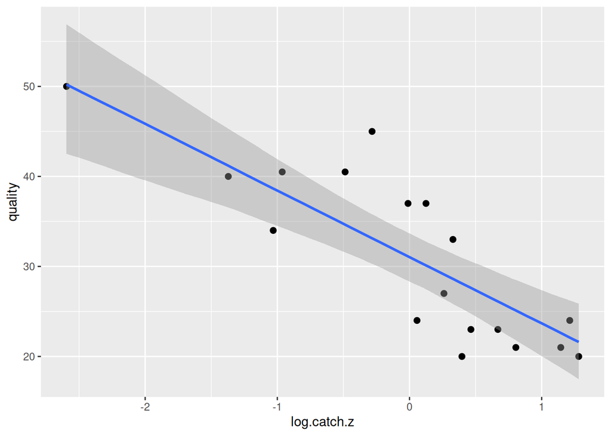

```r
plot(conditional_effects(fit2), points=TRUE)
```

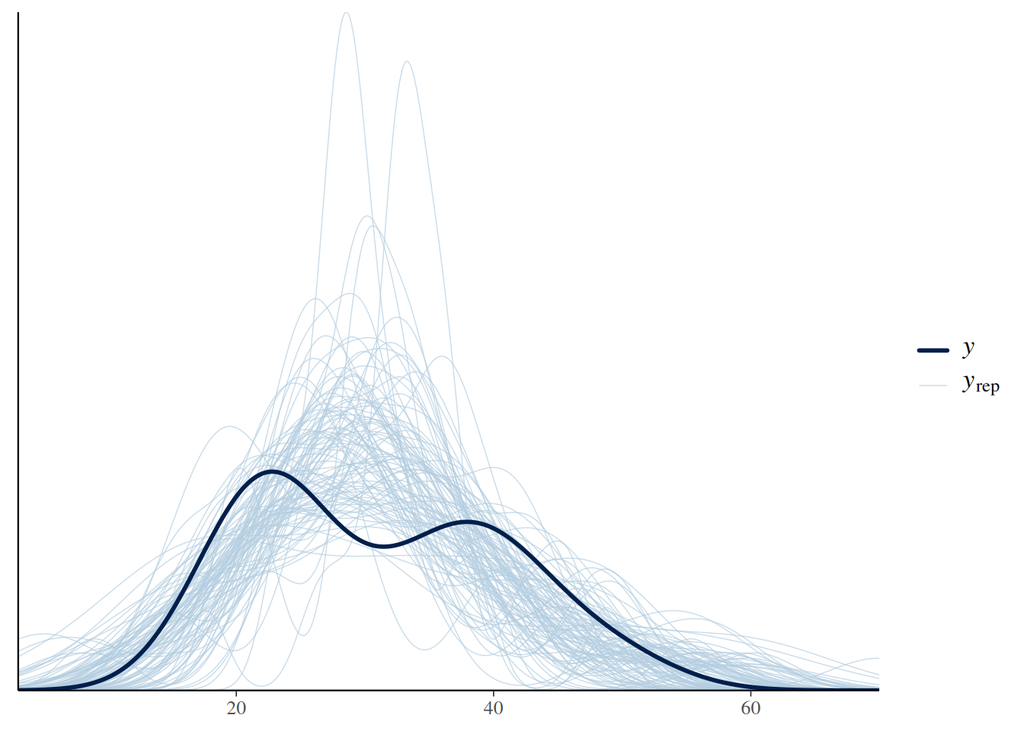

```r
pp_check(fit2, ndraws=100)
```

```
Using all posterior draws for ppc type 'scatter_avg' by default.
```

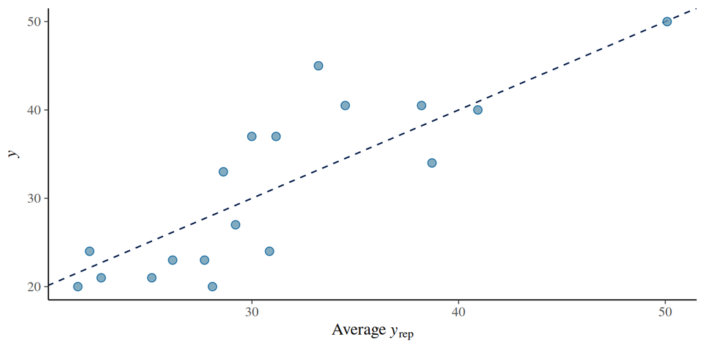

```r
pp_check(fit2, type="scatter_avg")
```

We see some deviation and maybe a pattern in the residuals, but since we only have 18 datapoints this could be merely by chance. We don’t want to include any other predictors, so we keep the model as is.

## (6) Model inference

With the scaled predictor, mean(x) and mean(x)+sd(x) correspond to predictor values of 0 and 1.

We generate fitted distributions of $\mu(0)$ and $\mu(1)$, and a distribution of the difference $\mu(0)-\mu(1)$. Then, compute its mean and 90%-quantile.

```r
fitted(fit2, newdata=data.frame(log.catch.z=0.0))
```

```
     Estimate Est.Error   Q2.5    Q97.5
[1,]  31.0414     1.339 28.317 33.65993
```

```r
fitted(fit2, newdata=data.frame(log.catch.z=1.0))
```

```
     Estimate Est.Error     Q2.5    Q97.5
[1,] 23.69945  1.863835 20.03582 27.36779
```

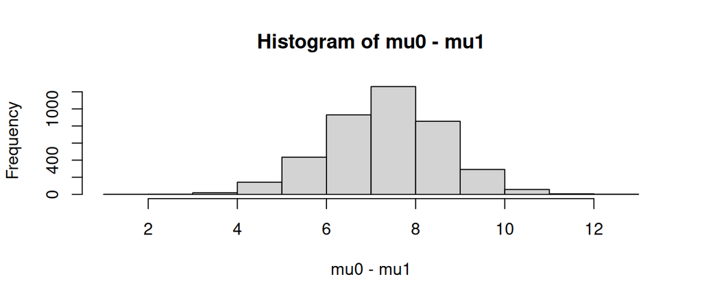

```r
mu0 = posterior_epred(fit2, newdata=data.frame(log.catch.z=0.0))
mu1 = posterior_epred(fit2, newdata=data.frame(log.catch.z=1.0))
hist(mu0-mu1)
```

```r
mean(mu0-mu1)
```

```
[1] 7.341951
```

```r
quantile(mu0-mu1, probs=c(0.05, 0.95))
```

```
      5%      95%
5.162335 9.338708
```

Alternatively, we can use the hypothesis function to get the same results.

```r
mus = fitted(fit2,
             newdata=data.frame(log.catch.z=c(0,1)),
             summary=F)
mus = as.data.frame(mus)
names(mus)=c("mu0","mu1")
hypothesis(mus, "mu0>mu1")
```

```
Hypothesis Tests for class :
       Hypothesis Estimate Est.Error CI.Lower CI.Upper Evid.Ratio Post.Prob Star
1 (mu0)-(mu1) > 0     7.34      1.28     5.16     9.34        Inf         1    *
---
'CI': 90%-CI for one-sided and 95%-CI for two-sided hypotheses.
'*': For one-sided hypotheses, the posterior probability exceeds 95%;
for two-sided hypotheses, the value tested against lies outside the 95%-CI.
Posterior probabilities of point hypotheses assume equal prior probabilities.
```

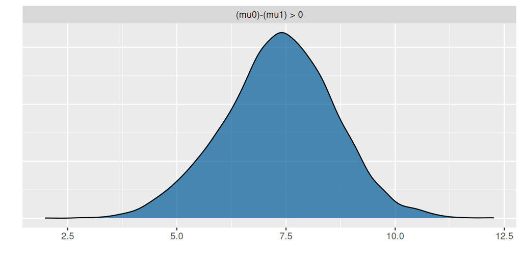

```r
plot(hypothesis(mus, "mu0>mu1"))
```